# Ensemble Project

### Build Decision Tree Model - Gini

```python
dTree = DecisionTreeClassifier(criterion = 'gini', random_state=1)
dTree.fit(X_train, y_train)
```

```
DecisionTreeClassifier(ccp_alpha=0.0, class_weight=None, criterion='gini',
                       max_depth=None, max_features=None, max_leaf_nodes=None,
                       min_impurity_decrease=0.0, min_impurity_split=None,
                       min_samples_leaf=1, min_samples_split=2,
                       min_weight_fraction_leaf=0.0, presort='deprecated',
                       random_state=1, splitter='best')
```

```python
print(dTree.score(X_train, y_train))
print(dTree.score(X_test, y_test))
```

```
1.0
0.8661489966940878
```

```python
#Reducing overfitting (Regularization)
dTreeGR = DecisionTreeClassifier(criterion = 'gini', max_depth = 3, random_state=1)
dTreeGR.fit(X_train, y_train)
print(dTreeGR.score(X_train, y_train))
print(dTreeGR.score(X_test, y_test))
```

```
0.8897090321942861
0.8918274775121089
```

```python
print (pd.DataFrame(dTreeGR.feature_importances_, columns = ["Imp"], index = X_train.columns))
```

```
                   Imp
age               0.00
education         0.00
default           0.00
balance           0.00
housing           0.00
loan              0.00
duration          0.80
campaign          0.00
previous          0.14
job_blue-collar   0.00
job_entrepreneur  0.00
job_housemaid     0.00
job_management    0.00
job_retired       0.00
job_self-employed 0.00
job_services      0.00
job_student       0.00
job_technician    0.00
job_unemployed    0.00
job_unknown       0.00
marital_married   0.00
marital_single    0.00
month_aug         0.00
month_dec         0.00
month_feb         0.00
month_jan         0.00
month_jul         0.00
month_jun         0.00
month_mar         0.03
month_may         0.00
month_nov         0.00
month_oct         0.00
month_sep         0.00
contact_telephone 0.00
contact_unknown   0.02
```

|  | Algorithm | Accuracy | Recall | Precision | f1_score | ROC AUC Score |
| --- | --- | --- | --- | --- | --- | --- |
| 0 | Logistic Regression | 0.90 | 0.29 | 0.61 | 0.40 | 0.63 |
| 0 | Decision Tree Regularised - Gini | 0.89 | 0.18 | 0.59 | 0.28 | 0.58 |

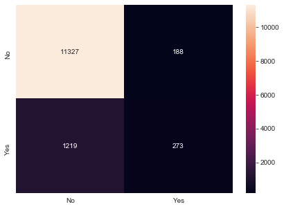

```python
y_predict = dTreeGR.predict(X_test)

cm=metrics.confusion_matrix(y_test, y_predict, labels=[0, 1])

df_cm = pd.DataFrame(cm, index = [i for i in ["No","Yes"]],
                  columns = [i for i in ["No","Yes"]])
plt.figure(figsize = (7,5))
sns.heatmap(df_cm, annot=True ,fmt='g')

tempResultsDf = pd.DataFrame({'Algorithm':['Decision Tree Regularised - Gini'],
                          'Accuracy': accuracy_score(y_test, y_predict),
                          'Recall':recall_score(y_test, y_predict),
                        'Precision':precision_score(y_test, y_predict),
                         'f1_score':f1_score(y_test, y_predict),
                             'ROC AUC Score':roc_auc_score(y_test, y_predict)})
resultsDf = pd.concat([resultsDf, tempResultsDf])
resultsDf = resultsDf[['Algorithm', 'Accuracy','Recall','Precision','f1_score','ROC AUC Score']]
resultsDf
```

### Build Bagging Model

```python
from sklearn.ensemble import BaggingClassifier
#use decision tree as the base for bagging
bgcl = BaggingClassifier(base_estimator=dTree, n_estimators=50,random_state=1)
#bgcl = BaggingClassifier(n_estimators=50,random_state=1)

bgcl = bgcl.fit(X_train, y_train)
```

```
0.8983624202352579
```

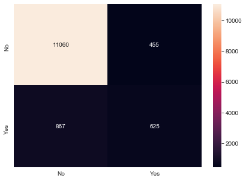

```python
y_predict = bgcl.predict(X_test)

print(bgcl.score(X_test , y_test))

cm=metrics.confusion_matrix(y_test, y_predict,labels=[0, 1])

df_cm = pd.DataFrame(cm, index = [i for i in ["No","Yes"]],
                  columns = [i for i in ["No","Yes"]])
plt.figure(figsize = (7,5))
sns.heatmap(df_cm, annot=True ,fmt='g')
```

```python
tempResultsDf = pd.DataFrame({'Algorithm':['Bagging'],
                          'Accuracy': accuracy_score(y_test, y_predict),
                          'Recall':recall_score(y_test, y_predict),
                        'Precision':precision_score(y_test, y_predict),
                         'f1_score':f1_score(y_test, y_predict),
                             'ROC AUC Score':roc_auc_score(y_test, y_predict)})
resultsDf = pd.concat([resultsDf, tempResultsDf])
resultsDf = resultsDf[['Algorithm', 'Accuracy','Recall','Precision','f1_score','ROC AUC Score']]
resultsDf
```

|  | Algorithm | Accuracy | Recall | Precision | f1_score | ROC AUC Score |
| --- | --- | --- | --- | --- | --- | --- |
| 0 | Logistic Regression | 0.90 | 0.29 | 0.61 | 0.40 | 0.63 |
| 0 | Decision Tree Regularised - Gini | 0.89 | 0.18 | 0.59 | 0.28 | 0.58 |
| 0 | Bagging | 0.90 | 0.42 | 0.58 | 0.49 | 0.69 |

### Adaboosting

```python
from sklearn.ensemble import AdaBoostClassifier
#abcl = AdaBoostClassifier(n_estimators=10, random_state=1)
abcl = AdaBoostClassifier( n_estimators=50,random_state=1)
abcl = abcl.fit(X_train, y_train)
```

```
0.8969785500115323
```

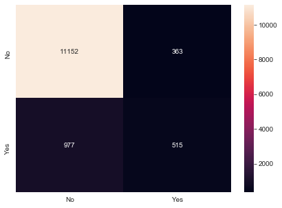

```python
y_predict = abcl.predict(X_test)
print(abcl.score(X_test , y_test))

cm=metrics.confusion_matrix(y_test, y_predict,labels=[0, 1])

df_cm = pd.DataFrame(cm, index = [i for i in ["No","Yes"]],
                  columns = [i for i in ["No","Yes"]])
plt.figure(figsize = (7,5))
sns.heatmap(df_cm, annot=True ,fmt='g')
```

```python
print (pd.DataFrame(abcl.feature_importances_, columns = ["Imp"], index = X_train.columns))
```

```
                   Imp
age               0.10
education         0.04
default           0.00
balance           0.06
housing           0.04
loan              0.02
duration          0.42
campaign          0.02
previous          0.02
job_blue-collar   0.00
job_entrepreneur  0.00
job_housemaid     0.00
job_management    0.00
job_retired       0.00
job_self-employed 0.00
job_services      0.00
job_student       0.00
job_technician    0.00
job_unemployed    0.00
job_unknown       0.00
marital_married   0.02
marital_single    0.00
month_aug         0.00
month_dec         0.02
month_feb         0.02
month_jan         0.02
month_jul         0.04
month_jun         0.02
month_mar         0.02
month_may         0.02
month_nov         0.02
month_oct         0.02
month_sep         0.02
contact_telephone 0.00
contact_unknown   0.04
```

```python
tempResultsDf = pd.DataFrame({'Algorithm':['Adaboosting'],
                          'Accuracy': accuracy_score(y_test, y_predict),
                          'Recall':recall_score(y_test, y_predict),
                        'Precision':precision_score(y_test, y_predict),
                         'f1_score':f1_score(y_test, y_predict),
                             'ROC AUC Score':roc_auc_score(y_test, y_predict)})
resultsDf = pd.concat([resultsDf, tempResultsDf])
resultsDf = resultsDf[['Algorithm', 'Accuracy','Recall','Precision','f1_score','ROC AUC Score']]
resultsDf
```

|  | Algorithm | Accuracy | Recall | Precision | f1_score | ROC AUC Score |
| --- | --- | --- | --- | --- | --- | --- |
| 0 | Logistic Regression | 0.90 | 0.29 | 0.61 | 0.40 | 0.63 |
| 0 | Decision Tree Regularised - Gini | 0.89 | 0.18 | 0.59 | 0.28 | 0.58 |
| 0 | Bagging | 0.90 | 0.42 | 0.58 | 0.49 | 0.69 |
| 0 | Adaboosting | 0.90 | 0.35 | 0.59 | 0.43 | 0.66 |

### Gradient Boosting

```python
from sklearn.ensemble import GradientBoostingClassifier
gbcl = GradientBoostingClassifier(n_estimators = 50,random_state=1)
gbcl = gbcl.fit(X_train, y_train)
```

```
0.9012070423618052
```

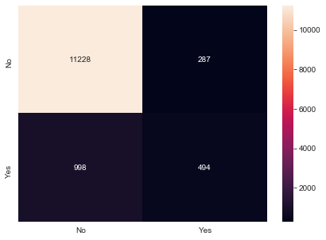

```python
y_predict = gbcl.predict(X_test)
print(gbcl.score(X_test, y_test))
cm=metrics.confusion_matrix(y_test, y_predict,labels=[0, 1])

df_cm = pd.DataFrame(cm, index = [i for i in ["No","Yes"]],
                  columns = [i for i in ["No","Yes"]])
plt.figure(figsize = (7,5))
sns.heatmap(df_cm, annot=True ,fmt='g')
```

```python
print (pd.DataFrame(gbcl.feature_importances_, columns = ["Imp"], index = X_train.columns))
```

```
                   Imp
age               0.04
education         0.00
default           0.00
balance           0.01
housing           0.07
loan              0.00
duration          0.56
campaign          0.01
previous          0.09
job_blue-collar   0.00
job_entrepreneur  0.00
job_housemaid     0.00
job_management    0.00
job_retired       0.00
job_self-employed 0.00
job_services      0.00
job_student       0.00
job_technician    0.00
job_unemployed    0.00
job_unknown       0.00
marital_married   0.01
marital_single    0.00
month_aug         0.00
month_dec         0.01
month_feb         0.00
month_jan         0.00
month_jul         0.00
month_jun         0.03
month_mar         0.04
month_may         0.00
month_nov         0.00
month_oct         0.03
month_sep         0.03
contact_telephone 0.00
contact_unknown   0.05
```

```python
tempResultsDf = pd.DataFrame({'Algorithm':['Gradient Boosting'],
                          'Accuracy': accuracy_score(y_test, y_predict),
                          'Recall':recall_score(y_test, y_predict),
                        'Precision':precision_score(y_test, y_predict),
                         'f1_score':f1_score(y_test, y_predict),
                             'ROC AUC Score':roc_auc_score(y_test, y_predict)})
resultsDf = pd.concat([resultsDf, tempResultsDf])
resultsDf = resultsDf[['Algorithm', 'Accuracy','Recall','Precision','f1_score','ROC AUC Score']]
resultsDf
```

|  | Algorithm | Accuracy | Recall | Precision | f1_score | ROC AUC Score |
| --- | --- | --- | --- | --- | --- | --- |
| 0 | Logistic Regression | 0.90 | 0.29 | 0.61 | 0.40 | 0.63 |
| 0 | Decision Tree Regularised - Gini | 0.89 | 0.18 | 0.59 | 0.28 | 0.58 |
| 0 | Bagging | 0.90 | 0.42 | 0.58 | 0.49 | 0.69 |
| 0 | Adaboosting | 0.90 | 0.35 | 0.59 | 0.43 | 0.66 |
| 0 | Gradient Boosting | 0.90 | 0.33 | 0.63 | 0.43 | 0.65 |

### Random Forest

```python
from sklearn.ensemble import RandomForestClassifier
rfcl = RandomForestClassifier(n_estimators = 50, random_state=1,max_features=12)
rfcl = rfcl.fit(X_train, y_train)
```

```
0.9011301606827093
```

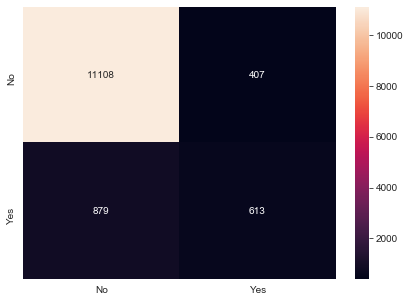

```python
y_predict = rfcl.predict(X_test)
print(rfcl.score(X_test, y_test))
cm=metrics.confusion_matrix(y_test, y_predict,labels=[0, 1])

df_cm = pd.DataFrame(cm, index = [i for i in ["No","Yes"]],
                  columns = [i for i in ["No","Yes"]])
plt.figure(figsize = (7,5))
sns.heatmap(df_cm, annot=True ,fmt='g')
```

```python
print (pd.DataFrame(rfcl.feature_importances_, columns = ["Imp"], index = X_train.columns))
```

```
                   Imp
age               0.12
education         0.03
default           0.00
balance           0.14
housing           0.03
loan              0.01
duration          0.33
campaign          0.05
previous          0.03
job_blue-collar   0.01
job_entrepreneur  0.00
job_housemaid     0.00
job_management    0.01
job_retired       0.01
job_self-employed 0.01
job_services      0.01
job_student       0.01
job_technician    0.01
job_unemployed    0.01
job_unknown       0.00
marital_married   0.02
marital_single    0.01
month_aug         0.01
month_dec         0.01
month_feb         0.01
month_jan         0.01
month_jul         0.01
month_jun         0.02
month_mar         0.02
month_may         0.01
month_nov         0.01
month_oct         0.01
month_sep         0.01
contact_telephone 0.01
contact_unknown   0.01
```

```python
tempResultsDf = pd.DataFrame({'Algorithm':['Random Forest'],
                          'Accuracy': accuracy_score(y_test, y_predict),
                          'Recall':recall_score(y_test, y_predict),
                        'Precision':precision_score(y_test, y_predict),
                         'f1_score':f1_score(y_test, y_predict),
                             'ROC AUC Score':roc_auc_score(y_test, y_predict)})
resultsDf = pd.concat([resultsDf, tempResultsDf])
resultsDf = resultsDf[['Algorithm', 'Accuracy','Recall','Precision','f1_score','ROC AUC Score']]
resultsDf
```

|  | Algorithm | Accuracy | Recall | Precision | f1_score | ROC AUC Score |
| --- | --- | --- | --- | --- | --- | --- |
| 0 | Logistic Regression | 0.90 | 0.29 | 0.61 | 0.40 | 0.63 |
| 0 | Decision Tree Regularised - Gini | 0.89 | 0.18 | 0.59 | 0.28 | 0.58 |
| 0 | Bagging | 0.90 | 0.42 | 0.58 | 0.49 | 0.69 |
| 0 | Adaboosting | 0.90 | 0.35 | 0.59 | 0.43 | 0.66 |
| 0 | Gradient Boosting | 0.90 | 0.33 | 0.63 | 0.43 | 0.65 |
| 0 | Random Forest | 0.90 | 0.41 | 0.60 | 0.49 | 0.69 |

###### For the given term deposit subscription prediction scenario I would consider Precision to be the most important metric. The model will need to maximise the True Positives prediction. Gradient Boosting generated the highest Precision (63%). However, as the given dataset is highly imbalanced (only 11% customers opted for Term Deposit), F1 Score and ROC AUC Score will also need to be considered. As a result, Random Forest, Bagging, and Gradient Boosting are top 3 models for the provided dataset